# A8-*Keegan Howes*

by *Keegan Howes* (*301234292*)

Novemeber 14, 2020

### Assignment 8 Instructions

1. Read [Sections 6.5 and 6.6 in Chapter 6](https://socviz.co/modeling.html#generate-predictions-to-graph) of SOCVIZ.
2. Read [CH 7](https://r4ds.had.co.nz/exploratory-data-analysis.html), [CH 15](https://r4ds.had.co.nz/factors.html), [CH 19](https://r4ds.had.co.nz/functions.html) and [CH 21](https://r4ds.had.co.nz/iteration.html) in R4DS.
3. Download the markdown file “A8-Your Name.Rmd” from Canvas. Change the name of the file so that your full name appears in the name of the file instead of the words “Your Name”. Change the title and author information at the top to reflect your information. **Independently** complete the steps in each section below, then *knit* your R Markdown Notebook into a `.html` file. Submit the completed `.Rmd` and `.html` file on Canvas. Submit the same `.html` file to the course Turnitin link. **Assignment 8 is due by 11:59PM on Sunday November 15. Assignments submitted late will lose one point per 10 minutes late. So 1 point will be deducted if submitted between 12:00-12:09 AM; -2 points 12:10-12:19 AM; …; -9 points 1:20-1:29 (since assignments are out of 10, no credit for anything after 1:30)**

### Part 1: Integrity Statement and Assignment References

In submitting this assignment to Canvas, I, **Keegan John Howes**, confirm that this work was independently completed and that I have appropriately listed all of my sources below. I understand that if any part of my answers (inlcluding the code I use) are similar enough to indicate non-independent work when compared to the answers from any other student in this course or from prior course materials, then I will receive zero points on this assignment. I also affirm that any answers or code copied or used from other resources online is appropriately referenced and if it is not appropriately referenced than I will receive zero points on this assignment.

I have used the following materials to complete this assignment: 1. [R4DS](https://r4ds.had.co.nz). 2. [SOCVIZ](https://socviz.co) 3. Course lecture videos on Canvas 4. [How to plot a ‘percentage plot’ with ggplot2](https://sebastiansauer.github.io/percentage_plot_ggplot2_V2/) 5.gss_sm data set

NEW: I have used the following R packages to complete this assignment. To replicate, install these packages first. 1.`tidyverse` 2. `gssr` 3. `broom`

### Part 2

For this assignment, you will be working with a subset of the General Social Survey (GSS) data created for the SOCVIZ book. You will need to install the `socviz` package which you can do by typing `devtools::install_github("kjhealy/socviz")` into your console.

```r
library(tidyverse)
```

```r
library(socviz)
data(gss_sm)
library(broom)
```

1. Create a modified data object from the `gss_sm` dataset that is part of the `gssr` package (make sure to load the `gssr` library) according to the following features:
   1. keep the following variables/columns: age, childs (number of children), degree, race, sex, region, income16, polviews, happy, zodiac, obama
   2. keep observations only if the `obama` variable is non-missing so that your data represents individuals who voted in the 2012 election.

Show the structue of your data using `str()`. Which of the columns are “Factor” format? Comment on what a “factor” variable is.

```r
gss_small <- select(gss_sm, age, childs, degree, race, sex, region, income16, polviews, happy, zodiac, obama)%>%filter(!is.na(obama))
str(gss_small)
```

```
## tibble [1,730 × 11] (S3: tbl_df/tbl/data.frame)
##  $ age     : num [1:1730] 47 61 72 43 55 53 71 32 60 76 ...
##   ..- attr(*, "label")= chr "AGE OF RESPONDENT"
##   ..- attr(*, "format.stata")= chr "%8.0g"
##   ..- attr(*, "labels")= Named num [1:3] 89 98 99
##   .. ..- attr(*, "names")= chr [1:3] "89 OR OLDER" "dk" "na"
##  $ childs  : num [1:1730] 3 0 2 4 2 2 4 3 5 7 ...
##   ..- attr(*, "label")= chr "NUMBER OF CHILDREN"
##   ..- attr(*, "format.stata")= chr "%8.0g"
##   ..- attr(*, "labels")= Named num [1:2] 8 9
##   .. ..- attr(*, "names")= chr [1:2] "EIGHT OR MORE" "DK NA"
##  $ degree  : Factor w/ 5 levels "Lt High School",..: 4 2 4 2 5 3 3 2 2 1 ...
##  $ race    : Factor w/ 3 levels "White","Black",..: 1 1 1 1 1 1 1 2 2 1 ...
##  $ sex     : Factor w/ 2 levels "Male","Female": 1 1 1 2 2 2 1 1 2 1 ...
##  $ region  : Factor w/ 9 levels "New England",..: 1 1 1 1 1 1 2 2 2 1 ...
##  $ income16: Factor w/ 26 levels "under $1 000",..: 26 19 21 26 26 20 20 8 10 18 ...
##  $ polviews: Factor w/ 7 levels "Extremely Liberal",..: 4 2 6 4 3 3 6 3 2 4 ...
##  $ happy   : Factor w/ 3 levels "Very Happy","Pretty Happy",..: 2 2 1 2 1 1 2 1 1 2 ...
##  $ zodiac  : Factor w/ 12 levels "Aries","Taurus",..: 11 8 12 4 8 8 9 7 11 6 ...
##  $ obama   : num [1:1730] 0 1 0 0 1 1 0 1 1 0 ...
```

**Only age, childs and Obama are not factors. Factors are another way of organizing categorical variables.**

2. Create a numeric variable for income that is equal to the midpoint of the category represented for each value of `income16`. For example, for the category “$10000 to 12499” your new income variable would be equal to 11250; for the category “$17500 to 19999” your new variable would be equal to 18750 for the category “$130000 to $149999”, your new variable would be equal to 140000. For the topcoded category, “$170000 or over” use 200000. I show on the lecture video how you might approach this using `case_when()`. Also create an indicator variable equal to 1 if female and 0 if male.

```r
gss_small <- mutate(gss_small, income = case_when(income16 == "under $1 000" ~ 500, income16 == "$1 000 to 2 999" ~1500, income16 == "$3 000 to 3 999" ~ 3500, income16 == "$4 000 to 4 999" ~4500, income16 =="$5 000 to 5 999" ~5500, income16 == "$6 000 to 6 999"~6500, income16 == "$7 000 to 7 999"~7500, income16 == "$8 000 to 9 999"~9000, income16 == "$10000 to 12499"~11250, income16 =="$12500 to 14999"~13750, income16 =="$15000 to 17499"~16250, income16 =="$17500 to 19999"~18750, income16 =="$20000 to 22499"~21250, income16 == "$22500 to 24999"~23750, income16 =="$25000 to 29999"~27500, income16 == "$30000 to 34999"~32500, income16 == "$35000 to 39999"~37500, income16 =="$40000 to 49999"~42500, income16 =="$50000 to 59999"~55000, income16 == "$60000 to 74999"~67500, income16 == "$75000 to $89999"~82500, income16 == "$90000 to $109999"~100000, income16 == "$110000 to $129999"~120000, income16 == "$130000 to $149999"~140000, income16 =="$150000 to $169999"~160000, income16 =="$170000 or over"~200000), female = case_when(sex == "Male"~0, sex == "Female"~1))
```

3. Create a “box-and-whisker” plot (`geom_boxplot`) that allows you to compare income across the group who voted for Obama (`obama==1`) and the group that voted for Romney (`obama==0`) in the 2012 election. Make the graph as clear as possible with titles, labels, etc. Write a brief comment on what is depicted by a box-and-whisker plot (can find a discussion of a boxplot in CH7 of R4DS) and what you learn about how income varies between Romney and Obama voters.

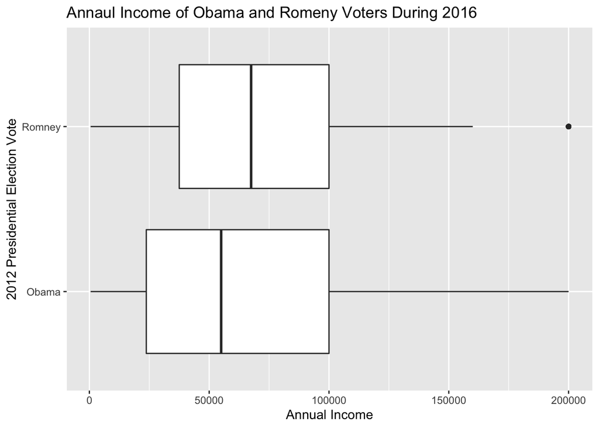

```r
gss_small <- mutate(gss_small, voted_for = ifelse(obama == "1", "Obama", "Romney"))
ggplot(data = gss_small, mapping = aes(x = income, y = voted_for )) + geom_boxplot() + labs(x = "Annual Income", y = "2012 Presidential Election Vote", title = "Annaul Income of Obama and Romeny Voters During 2016")
```

**It appear the Romney voters had a higher median income compared to Obama votes, but Obama votes had a higher range of incomes, it also appears that there are outliers of Romney voters with very high incomes.**

4. Using another visualization technique from [R4DS CH 7.5](https://r4ds.had.co.nz/exploratory-data-analysis.html) to understand covariation, compare any of the other variables in your data across Obama vs. Romney voters. Do not use the `geom_boxplot()` - be creative and try some of the other teqniques. **No two students should have the same or similar answers for this questions. While you are being creative - make sure to go sign the integrity statment at the top :)**

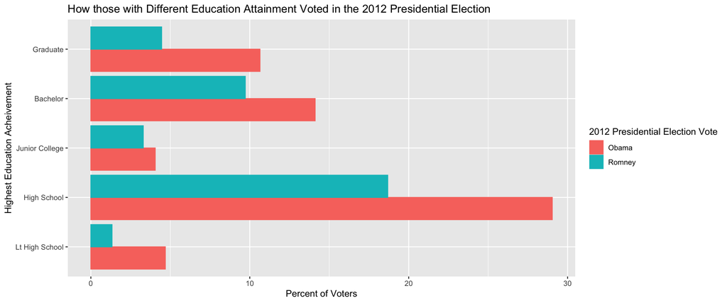

```r
gss_smaller <- filter(gss_small, !is.na(degree))
ggplot(data= gss_smaller, mapping = aes(x = degree, colour = voted_for, fill = voted_for)) +geom_bar(position = "dodge", na.rm = TRUE, aes(y =100* (..count..)/sum(..count..))) +coord_flip()+labs(y = "Percent of Voters", x ="Highest Education Acheivement", fill = "2012 Presidential Election Vote", colour = "2012 Presidential Election Vote", title = "How those with Different Education Attainment Voted in the 2012 Presidential Election")
```

5. Estimate a linear regression model using the `lm` function where the dependent variable is the indicator variable for whether an indivdual voted for Obama in 2012 (`obama`) and the following variables are the independent regressor variables: `age, childs, degree, race,` and the female indicator variable and income variable you created in Q2. Display your regression output. Since your dependent variable is either zero or one, your coefficients can be interpreted as a change in the probability of voting for Obama associated with a one-unit change in your regressor. So if you have a coefficient equal to 0.05 this means that a one unit increase in your regressor is associated with a 5 percentage point increase in the probability an individual voted for Obama. What is the increase in the probability of voting for Obama with a 10,000 increase in income in this model? How does this compare to your visualization in Q3?

```r
reg_q5 <- lm(obama~age + childs + degree + race + female + income, data = gss_small)
summary(reg_q5)
```

```
##
## Call:
## lm(formula = obama ~ age + childs + degree + race + female +
##     income, data = gss_small)
##
## Residuals:
##      Min       1Q   Median       3Q      Max
## -1.04000 -0.48143  0.08592  0.42344  0.72694
##
## Coefficients:
##                        Estimate Std. Error t value Pr(>|t|)
## (Intercept)           7.787e-01  6.920e-02  11.253  < 2e-16 ***
## age                  -1.541e-03  7.513e-04  -2.051 0.040444 *
## childs               -1.978e-02  7.737e-03  -2.557 0.010657 *
## degreeHigh School    -1.257e-01  5.164e-02  -2.435 0.015011 *
## degreeJunior College -1.478e-01  6.486e-02  -2.278 0.022846 *
## degreeBachelor       -8.193e-02  5.641e-02  -1.452 0.146622
## degreeGraduate        4.577e-02  5.974e-02   0.766 0.443731
## raceBlack             3.966e-01  3.122e-02  12.706  < 2e-16 ***
## raceOther             1.657e-01  4.751e-02   3.488 0.000501 ***
## female                6.295e-02  2.291e-02   2.748 0.006069 **
## income               -9.072e-07  2.369e-07  -3.830 0.000133 ***
## ---
## Signif. codes:  0 '***' 0.001 '**' 0.01 '*' 0.05 '.' 0.1 ' ' 1
##
## Residual standard error: 0.4481 on 1579 degrees of freedom
##   (140 observations deleted due to missingness)
## Multiple R-squared:  0.1462, Adjusted R-squared:  0.1408
## F-statistic: 27.03 on 10 and 1579 DF,  p-value: < 2.2e-16
```

**A $10,000 increase in income would result in a decrease of 0.9072% of voting for Obama. This is lines up with our graph from Q3 as Romney voters where generally richer than Obama voters.**

6. Follow the example in [Section 6.5.1 of SOCVIZ](https://socviz.co/modeling.html#tidy-model-objects-with-broom) and plot the estimates for the education, race, and female regressors similar to Figure 6.6 with estimates and their associated confidence intervals. Note how the `lm()` function treats factor variables (I will talk about this in the lecture video) and keep all the regressors related to education, race and female to plot. You will have to filter your tidy dataset of results to select just the coefficients of interest. Comment on which education group had the highest probability of voting for Obama holding all the other variables constant. Can you say with confidence that this difference is not zero? Explain why or why not.

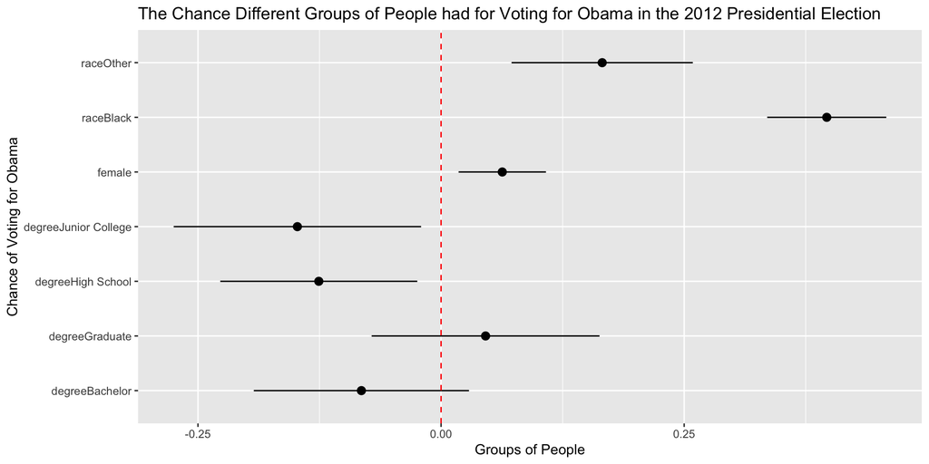

```r
reg_tidy <- tidy(reg_q5, conf.int = TRUE)%>%filter(str_detect(term, "degree")| str_detect(term, "race") |term =="female")

ggplot(data = reg_tidy, mapping = aes(x = term, y = estimate, ymin = conf.low, ymax = conf.high)) + geom_pointrange() +coord_flip()+geom_hline(yintercept = 0, linetype= "dashed", colour = "red") +labs(x = "Chance of Voting for Obama", y = "Groups of People", title = "The Chance Different Groups of People had for Voting for Obama in the 2012 Presidential Election")
```

**Those with a graduate degree had the highest chance of voting for Obama. We cannot say with confidence that this difference is not zero because the confidence interval of those with graduate degrees crossing our line red line of 0.**

7. We are now going to work on communicating results of how the association between gender and voting for Obama varies across the different regions in the US. Our goal will be a figure that looks similar to [Figure 6.9 in SOCVIZ](https://socviz.co/modeling.html#tidy-model-objects-with-broom) where region is on the horizontal axis but we will not have seperate groups (colors). We will only have one estimate for each region. Try to follow the example in 6.6 (also will discuss an example in lectture videos). Use the same dependent and independent variables as in Q5 for your `lm()` model. Describe your plot. What do the estimated coefficients measure? For which region is the difference between females and males in terms of voting for Obama the greatest? In which region is the difference the smallest?

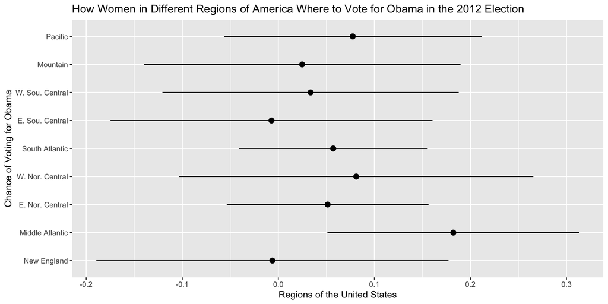

```r
regFun <- function(dataInput){
lm(obama~age + childs + degree + race + female + income, data = dataInput)

}
gss_group <- gss_small%>%group_by(region)%>%nest()%>%mutate(model = map(data, regFun))%>%mutate(tidy_model = map(model, tidy))%>%unnest(tidy_model, .drop =TRUE)%>%filter(term =="female")
ggplot(data =gss_group, mapping = aes(x = region, y = estimate, ymin = estimate-1.96*std.error, ymax = estimate + 1.96*std.error)) +geom_pointrange()+coord_flip()+labs(y = "Regions of the United States", x = "Chance of Voting for Obama", title ="How Women in Different Regions of America Where to Vote for Obama in the 2012 Election")
```

**The estimate coefficients refer how likely a women in a region was going to vote for Obama in the 2012 election compared to men. Middle America had the highest difference for voting between men and women. The East South Central region and the lowest difference between men and women for voting for Obama.**

8. Get your creative juices flowing! Go back to your dataset from Q1 or to the original `gss_sm` object and look through the types of variable captured. Propose your own analysis. Describe a linear model that you will estimate and why you think the model is interesting. What is your dependent variable (do not use the obama variable as the dependent variable)? What are your independent regressors? Choose one of the independent regressors as your **key regressor of interest** (something other than gender as we did above) and create a visualization helping to depict the covariation between this variable and your dependent variable (boxplot? scatterplot?). Use [Section 7.5 of R4DS](https://r4ds.had.co.nz/exploratory-data-analysis.html) for inspiration. Estimate your model using the full GSS sample and interpret the coefficient for your key regressor of interest. Then propose investigating how this relationship varies across different subsamples (don’t use region like we did above) and create a visualization displaying the estimate across different groups similar to what we did in the previous question. Be creative! Be original! Your idea should not overlap with anyone in the class.

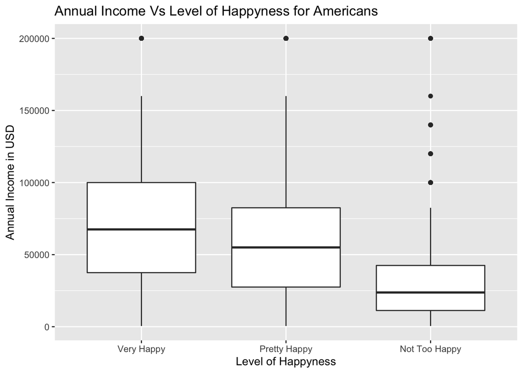

```r
data_kh <- mutate(gss_sm, income = case_when(income16 == "under $1 000" ~ 500, income16 == "$1 000 to 2 999" ~1500, income16 == "$3 000 to 3 999" ~ 3500, income16 == "$4 000 to 4 999" ~4500, income16 =="$5 000 to 5 999" ~5500, income16 == "$6 000 to 6 999"~6500, income16 == "$7 000 to 7 999"~7500, income16 == "$8 000 to 9 999"~9000, income16 == "$10000 to 12499"~11250, income16 =="$12500 to 14999"~13750, income16 =="$15000 to 17499"~16250, income16 =="$17500 to 19999"~18750, income16 =="$20000 to 22499"~21250, income16 == "$22500 to 24999"~23750, income16 =="$25000 to 29999"~27500, income16 == "$30000 to 34999"~32500, income16 == "$35000 to 39999"~37500, income16 =="$40000 to 49999"~42500, income16 =="$50000 to 59999"~55000, income16 == "$60000 to 74999"~67500, income16 == "$75000 to $89999"~82500, income16 == "$90000 to $109999"~100000, income16 == "$110000 to $129999"~120000, income16 == "$130000 to $149999"~140000, income16 =="$150000 to $169999"~160000, income16 =="$170000 or over"~200000), female = case_when(sex == "Male"~0, sex == "Female"~1), happyness = case_when(happy =="Pretty Happy"~1, happy =="Very Happy"~2, happy =="Not Too Happy"~0))%>%filter(!is.na(happy))%>%filter(!is.na(degree))

data_kh <- select(data_kh, happyness, income, female, religion, age, childs, degree, race, happy)



ggplot(data=data_kh, mapping = aes(x = income, y= happy)) +geom_boxplot() +coord_flip()+labs(x = "Annual Income in USD", y = "Level of Happyness", title = "Annual Income Vs Level of Happyness for Americans")
```

**My dependent variable is happy and it is being regressed on income, female age, race and childs. My key regress of interest is income.**

```r
reg8 <- lm(happyness ~income + age + childs + race + female, data = data_kh)
summary(reg8)
```

```
##
## Call:
## lm(formula = happyness ~ income + age + childs + race + female,
##     data = data_kh)
##
## Residuals:
##      Min       1Q   Median       3Q      Max
## -1.53937 -0.25251 -0.05555  0.58479  1.13437
##
## Coefficients:
##               Estimate Std. Error t value Pr(>|t|)
## (Intercept)  9.396e-01  4.465e-02  21.042   <2e-16 ***
## income       2.918e-06  2.399e-07  12.162   <2e-16 ***
## age          2.809e-04  7.754e-04   0.362   0.7171
## childs      -4.090e-03  8.099e-03  -0.505   0.6136
## raceBlack   -7.006e-02  3.442e-02  -2.036   0.0419 *
## raceOther    6.992e-02  4.367e-02   1.601   0.1095
## female       2.639e-04  2.484e-02   0.011   0.9915
## ---
## Signif. codes:  0 '***' 0.001 '**' 0.01 '*' 0.05 '.' 0.1 ' ' 1
##
## Residual standard error: 0.6253 on 2572 degrees of freedom
##   (275 observations deleted due to missingness)
## Multiple R-squared:  0.06234,    Adjusted R-squared:  0.06016
## F-statistic:  28.5 on 6 and 2572 DF,  p-value: < 2.2e-16
```

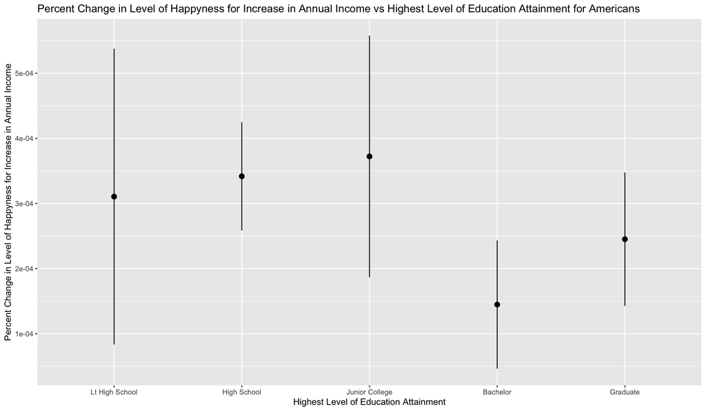

```r
regFun2 <- function(dataInput){
lm(happyness~income + age + childs + race + female, data = dataInput)

}

data_grouped<- data_kh%>%group_by(degree)%>%nest()%>%mutate(model = map(data, regFun2))%>%mutate(tidy_model = map(model, tidy))%>%unnest(tidy_model, .drop =TRUE)%>%filter(term =="income")
ggplot(data=data_grouped, mapping = aes(x = degree, y = (estimate*100), ymin = (estimate-1.96*std.error)*100, ymax = (estimate + 1.96*std.error)*100)) +geom_pointrange()  + labs(y = "Percent Change in Level of Happyness for Increase in Annual Income", x = "Highest Level of Education Attainment", title = "Percent Change in Level of Happyness for Increase in Annual Income vs Highest Level of Education Attainment for Americans")
```

**DON’T FORGET TO PUT YOUR NAME IN THE INTEGRITY STATEMENT IN PART 1 AND SUMBIT YOUR HTML FILE TO TURNITIN!**